### MB5370 - Workshop Assignment

### Module 04 - Data Science in R

### April 10 2025

### Uploading and viewing dataset

```r
getwd()
```

```
## [1] "/Users/alexanderbarkley/Desktop/Techniques 1 - Modules/Module 4 Workshops/Module4-workshops-git/MB5370_Mod4_Alex/code"
```

```r
library(dplyr)
library(ggplot2)
library(forcats)
library(RColorBrewer)
library (tidyverse)
library(janitor)


shark <-
  read.csv("../data/QFISH Assigment shark dataset.csv") |> #evaluating from root directory
  row_to_names(row_number = 2, remove_rows_above = FALSE) |>
  clean_names()

head(shark)
#view(shark)
as_tibble(shark)
```

### Extracting relevant species/taxa data from the larger dataframe - sharks

```r
shark_catch <-
  shark |>
  select (area | contains ("shark")) |> # keep "area" and all columns that contain the word "shark"
  row_to_names(row_number = 1) |> # Move the first row of the dataset into the column names
  rename(Area = 1) |> # Rename the first column to "Area" for clarity
  mutate (across(-c(Area), as.numeric)) # Convert all columns except "Area" to numeric values

shark_catch
```

### Turtles

```r
turtle_catch <-
  shark |>
  select (area | contains ("turtle")) |>
  row_to_names(row_number = 1) |>
  rename(Area = 1) |>
  mutate (across(-c(Area), as.numeric))

turtle_catch
```

### Mammals

```r
mammal_catch <-
  shark |>
  select (area | contains ("mammal")) |>
  row_to_names(row_number = 1) |>
  rename(Area = 1) |>
  mutate (across(-c(Area), as.numeric))

mammal_catch
```

### Other

```r
other_catch <-
  shark |>
  select (area | contains ("other")) |>
  row_to_names(row_number = 1) |>
  rename(Area = 1) |>
  mutate (across(-c(Area), as.numeric))

other_catch
```

### Pivoting wide tables longer

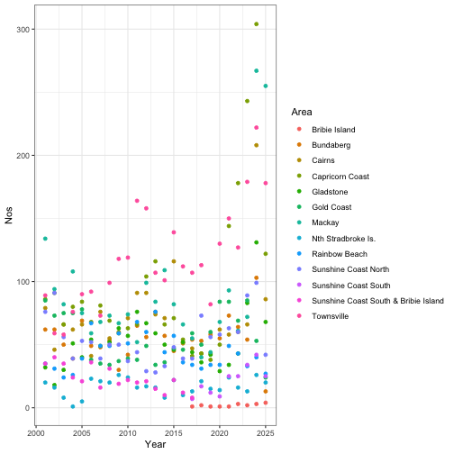

```r
shark_catch_long <-
  shark_catch |>
  pivot_longer(!Area, names_to = "Year", values_to = "Nos") #reshape from wide to long; keeping area column as is and all other column names (previously years) become values in a new 'Year' column. Their corresponding values go into a new "Nos" (number of sharks) column
shark_catch_long


# Plotting the data
shark_catch_long |>
  filter(Area != "Grand Total") |>
  mutate(Year = as.numeric(Year)) |>        # change "Year" to numeric
  ggplot(aes(x = Year, y = Nos, group = Area, colour = Area, fill = Area)) +
  geom_point() +
  theme_bw() +
  labs(x = "Year", y = "Nos")
```

### Attempt 1

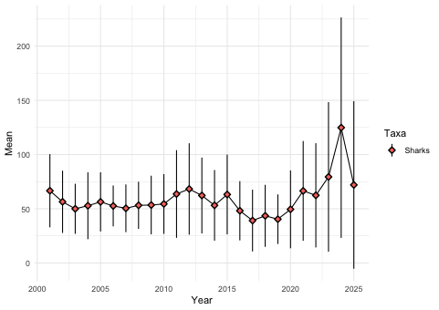

```r
# Summarise statistics of shark catches by year

shark_stats <-
  shark_catch_long |>                     # Using the long-format dataset for sharks
  filter(Area != "Grand Total") |>        # Excluding total summary
  group_by(Year) |>                       # Grouping data by calendar year
  summarise(
    Mean = mean(Nos, na.rm = TRUE),       # Calculating the mean number of shark catches
    SD = sd(Nos, na.rm = TRUE)            # Calculating the standard deviation
  ) |>
  mutate(Year = as.numeric(Year)) |>      # Ensures the year is treated as numeric
  mutate(Taxa = "Sharks")                 # Adds a new column identifying this group as "Sharks"

# View
shark_stats


# Creating a plot of mean shark catches over time with error bars

ggplot(data = shark_stats, aes(x = Year, y = Mean, fill = Taxa, shape = Taxa), colour = "black") +
  geom_line() +                                                           # Draws a line connecting yearly mean values
  geom_pointrange(aes(ymin = Mean - SD, ymax = Mean + SD), size = 0.5) +  # Adds points with vertical error bars
  scale_shape_manual(values = c(23, 24)) +
  theme_minimal()
```

```r
## then ggsave if you want
```

### Other data statistics

```r
# Converting turtle_catch from wide to long format

turtle_catch_long <-
  turtle_catch |>
  pivot_longer(
    !Area,                          # Keep 'Area' column fixed; pivot all others
    names_to = "Year",             # The old column names (years) go into a new column called 'Year'
    values_to = "Nos"              # The values from the pivoted columns go into 'Nos'
  )

# Step 2: Summarise turtle catch statistics per year

turt_stats <-
  turtle_catch_long |>
  filter(Area != "Grand Total") |>  #Excluding total
  group_by(Year) |>                 # Group the data by "Year" so we can calculate yearly stats
  summarise(
    Mean = mean(Nos, na.rm = TRUE), # Calculate the mean number of turtle catches for each year
    SD = sd(Nos, na.rm = TRUE)      # Calculate the standard deviation of catches per year
  ) |>
  mutate(Year = as.numeric(Year)) |>
  mutate(Taxa = "Turtles")

# View
turt_stats

### This same steps were taken for the following taxa categories.

# Mammals
mammal_catch_long <-
  mammal_catch |>
  pivot_longer(!Area, names_to = "Year", values_to = "Nos")
mammal_catch_long

mam_stats <-
mammal_catch_long |>
  filter(Area != "Grand Total") |>
  group_by(Year) |>
  summarise(Mean = mean(Nos, na.rm = TRUE),
            SD = sd(Nos, na.rm = TRUE)) |>
  mutate(Year = as.numeric(Year)) |>
  mutate(Taxa = "Mammals")
mam_stats

#Other
other_catch_long <-
  other_catch |>
  pivot_longer(!Area, names_to = "Year", values_to = "Nos")
other_catch_long

other_stats <-
other_catch_long |>
  filter(Area != "Grand Total") |>
  group_by(Year) |>
  summarise(Mean = mean(Nos, na.rm = TRUE),
            SD = sd(Nos, na.rm = TRUE)) |>
  mutate(Year = as.numeric(Year)) |>
  mutate(Taxa = "Other")
other_stats

### REMOVE GRAND TOTALS WHEN PLOTTING - DO SEPARATE
```

### Ben’s example

```r
shark_program <-
  read_csv("../data/QFISH Assigment shark dataset.csv") |>
  row_to_names(row_number = 2, remove_rows_above = FALSE) |> # Variable names are meaningless, so remove
  clean_names() # But we want
head(shark_program)
```

### Making new stats

```r
shark_catch <-
  shark_program |>
  select(area | contains("shark")) |>
  row_to_names(row_number = 1) |>
  rename(Area = 1) |>
  mutate(across(-c(Area), as.numeric))

turtle_catch <-
  shark_program |>
  select(area | contains("turtle")) |>
  row_to_names(row_number = 1) |>
  rename(Area = 1) |>
  mutate(across(-c(Area), as.numeric))

mammal_catch <-
  shark_program |>
  select(area | contains("mammal")) |>
  row_to_names(row_number = 1) |>
  rename(Area = 1) |>
  mutate(across(-c(Area), as.numeric))

other_catch <-
  shark_program |>
  select(area | contains("other")) |>
  row_to_names(row_number = 1) |>
  rename(Area = 1) |>
  mutate(across(-c(Area), as.numeric))

head(shark_catch, n = 2)
```

### Pivot wide tibbles longer

```r
shark_catch_long <-
shark_catch |>
  pivot_longer(!Area, names_to = "Year", values_to = "Nos")
shark_catch_long

turtle_catch_long <-
  turtle_catch |>
  pivot_longer(!Area, names_to = "Year", values_to = "Nos")
turtle_catch_long
```

### Make stats tibbles

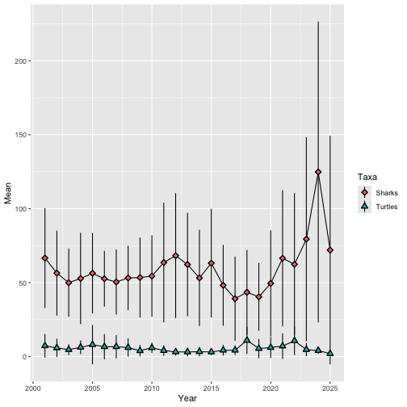

```r
shark_stats <-
shark_catch_long |>
  filter(Area != "Grand Total") |>
  group_by(Year) |>
  summarise(Mean = mean(Nos, na.rm = TRUE),
            SD = sd(Nos, na.rm = TRUE)) |>
  mutate(Year = as.numeric(Year)) |>
  mutate(Taxa = "Sharks")
shark_stats

turtle_stats <-
turtle_catch_long |>
  filter(Area != "Grand Total") |>
  group_by(Year) |>
  summarise(Mean = mean(Nos, na.rm = TRUE),
            SD = sd(Nos, na.rm = TRUE)) |>
  mutate(Year = as.numeric(Year)) |>
  mutate(Taxa = "Turtles")
turtle_stats

combine_stats <-
  bind_rows(shark_stats, turtle_stats)

#Plot
ggplot(data = combine_stats, aes(x =Year, y = Mean, fill = Taxa, shape = Taxa), colour = "black") +
  geom_line() +
  geom_pointrange(aes(ymin = Mean - SD, ymax = Mean + SD)) +
    scale_shape_manual(values = c(23, 24))
```

# Assignment Plots

### Looking at total shark catches per area

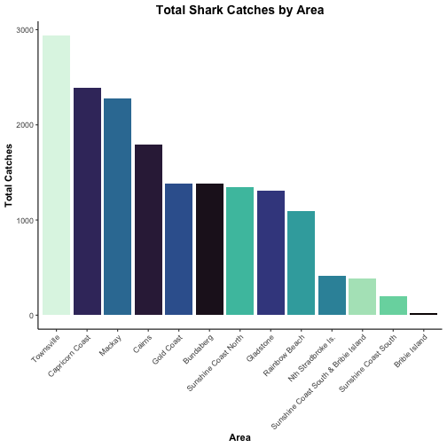

```r
library(viridis)

# Create a summary table with total catches per area (excluding the Grand Total row)
area_totals <- shark_catch_long |>
  filter(Area != "Grand Total") |>
  group_by(Area) |>                      # Group by location
  summarise(Total = sum(Nos, na.rm = TRUE)) |>  # Sum all catch values for each area
  arrange(desc(Total))                   # Arranging areas from highest to lowest catch

# View the resulting summary table
print(area_totals)

# Plot total catches by area
ggplot(area_totals, aes(x = reorder(Area, -Total), y = Total, fill = Area)) +
  geom_bar(stat = "identity") +                      # Plot bars representing total values
  scale_fill_viridis_d(option = "G") +
  theme_classic() +
  labs(
    title = "Total Shark Catches by Area",
    x = "Area",
    y = "Total Catches",
    fill = "Area"
  ) +
  theme(
    axis.text.x = element_text(angle = 45, hjust = 1), # Rotate x-axis labels for readability
    plot.title = element_text(face = "bold", hjust = 0.5, size = 14),  # Center and bold title
    axis.title = element_text(face = "bold"),          # Bold axis titles
    legend.position = "none"                           # Removes legend if labels are already on x-axis
  )
```

### Looking at time series of all the taxa

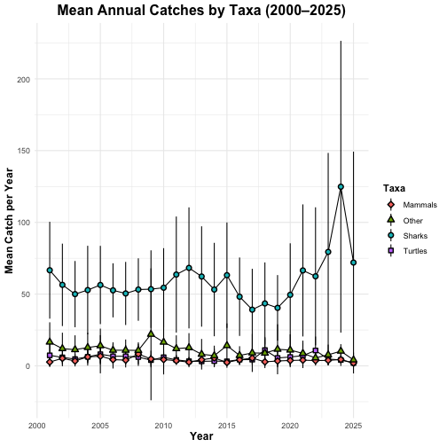

```r
combine_stats <-
  bind_rows(shark_stats, turtle_stats, mam_stats, other_stats)

# Creating time series scatterplot of mean catches by taxa for all years
ggplot(data = combine_stats, aes(x = Year, y = Mean, fill = Taxa, shape = Taxa)) +
  geom_line(aes(group = Taxa), colour = "black") +  # Adds black line for each Taxa
  geom_pointrange(aes(ymin = Mean - SD, ymax = Mean + SD), colour = "black") +  # Points + SD error bars
  scale_shape_manual(values = c(23, 24, 21, 22)) +  # Adds a third shape for another taxa if present (like "Other")
  labs(
    title = "Mean Annual Catches by Taxa (2000–2025)",
    x = "Year",
    y = "Mean Catch per Year",
    shape = "Taxa",
    fill = "Taxa"
  ) +
  theme_minimal() +  # Clean theme
  theme(
    plot.title = element_text(hjust = 0.5, face = "bold", size = 16),
    axis.title.x = element_text(face = "bold", size = 12),
    axis.title.y = element_text(face = "bold", size = 12),
    legend.title = element_text(face = "bold")
  )
```

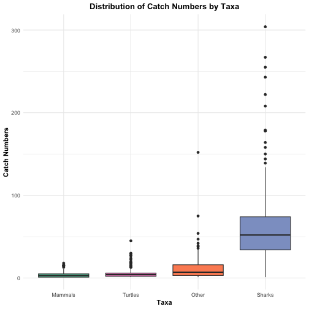

```r
# Looking at other ways to visualise this - boxplot

sharks <- shark_catch_long |>
  filter(Area != "Grand Total") |>
  mutate(Taxa = "Sharks")

turtles <- turtle_catch_long |>
  filter(Area != "Grand Total") |>
  mutate(Taxa = "Turtles")

mammals <- mammal_catch_long |>
  filter(Area != "Grand Total") |>
  mutate(Taxa = "Mammals")

others <- other_catch_long |>
  filter(Area != "Grand Total") |>
  mutate(Taxa = "Other")

# Combine all taxa datasets into one dataframe
catch_all <- bind_rows(sharks, turtles, mammals, others)

# Create a boxplot
ggplot(
  data = catch_all,
  aes(
    x = fct_reorder(Taxa, Nos, .fun = median),  # Reorder taxa by median catch for visual clarity
    y = Nos,
    fill = Taxa
  )
) +
  geom_boxplot() +
  theme_minimal() +
  labs(
    title = "Distribution of Catch Numbers by Taxa",
    x = "Taxa",
    y = "Catch Numbers"
  ) +
  scale_fill_brewer(palette = "Set2") +
  theme(
    plot.title = element_text(face = "bold", hjust = 0.5),  # Center and bold title
    axis.title = element_text(face = "bold"),               # Bold axis labels
    legend.position = "none"                                # Remove legend (redundant with x-axis)
  )
```

For the scatterplot: The graph shows the mean annual catch numbers for four taxa (Sharks, Turtles, Mammals, and Other) recorded across 13 sites from 2000 to 2025. Sharks consistently had the highest mean catch rates, with a notable increase after 2020, peaking around 2024. In contrast, the other groups (Turtles, Mammals, and Other) maintained relatively low and stable catch rates over the years. Error bars represent standard deviation, indicating year-to-year variability. The consistently low means and narrow error bars for non-shark taxa suggest limited changes in catch trends, while the increasing trend and wider variation in shark catches may reflect shifts in fishing effort, population dynamics, or reporting practices in recent years. The other taxa are not very visible on the graph however, as they overlap, therefore a boxplot to show the total catch for each taxa would be relevant.

### Looking at bycatch of other taxa as effort for shark catching increases

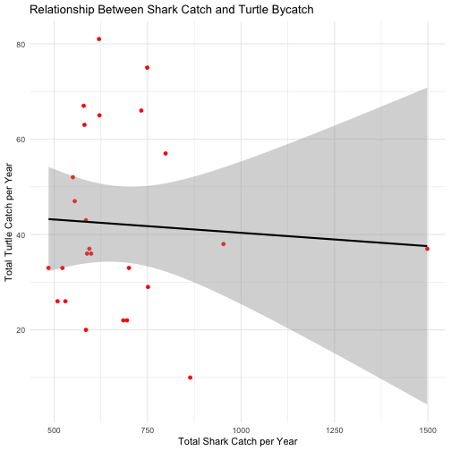

```r
# Summarise total shark catch per year
shark_yearly <- shark_catch_long |>
  filter(Area != "Grand Total") |>
  group_by(Year) |>
  summarise(SharkTotal = sum(Nos, na.rm = TRUE))

# Summarise total turtle catch per year
turtle_yearly <- turtle_catch_long |>
  filter(Area != "Grand Total") |>
  group_by(Year) |>
  summarise(TurtleTotal = sum(Nos, na.rm = TRUE))  # Sum turtle catches for each year

# Merge the two summaries into one table using Year as the key
bycatch_data <- left_join(shark_yearly, turtle_yearly, by = "Year")
# Now we have one row per year, with total shark and turtle catches side by side

# Plotting total turtle catch vs. shark catch per year
ggplot(bycatch_data, aes(x = SharkTotal, y = TurtleTotal)) +
  geom_point(color = "red", size = 1.5) +               # Add points for each year
  geom_smooth(method = "lm", se = TRUE, color = "black") + # Add linear regression line with confidence interval
  theme_minimal() +                                        # Use clean minimal theme
  labs(
    title = "Relationship Between Shark Catch and Turtle Bycatch",
    x = "Total Shark Catch per Year",
    y = "Total Turtle Catch per Year"
  )
```

The scatterplot illustrates the relationship between total shark catch and total turtle catch per year.Each point represents a single year, and the trendline indicates a very slight negative relationship between the two variables. However, the broad confidence interval suggests high variability and low statistical confidence in this trend. Overall, there is no strong evidence to suggest that increases in shark catch lead to increases in turtle bycatch.

### Converting markdown file to html to put on website

```r
library(knitr)
library(markdown)

getwd()
```

```
## [1] "/Users/alexanderbarkley/Desktop/Techniques 1 - Modules/Module 4 Workshops/Module4-workshops-git/MB5370_Mod4_Alex/code"
```

```r
knit("Assignment Module 4.Rmd") # produces a markdown (.md) file in your folder.
```

```
## Error in parse_block(g[-1], g[1], params.src, markdown_mode): Duplicate chunk label 'setup', which has been used for the chunk:
## knitr::opts_chunk$set(echo = TRUE)
```

```r
markdownToHTML("Assignment Module 4.md",
"Assignment Moduoe 4.html", fragment.only=TRUE)
```